# Лабораторная работа №2

Дисциплина “Операционные системы”

Демидович.Н.М

Российский университет дружбы народов, Москва, Россия

18 февраля 2023

# Докладчик

- Демидович Никита Михайлович
- Студент группы НКАбд-01-22
- Кафедра прикладной информатики и теории вероятностей
- Российский университет дружбы народов
- 1132221550@pfur.ru
- https://github.com/nikdem1

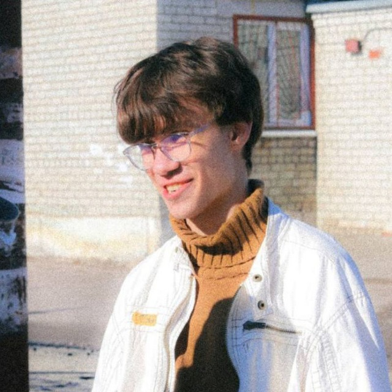

# Цели и задачи

## Цели лабораторной работы

- 1. Изучение идеологию средств контроля версий.
- 2. Применение средств контроля версий.
- 3. Приобрести практические навыки по работе с системой git.

## Основные задачи

- 1. Создать базовую конфигурацию для работы с git.
- 2. Создать ключ SSH.
- 3. Создать ключ PGP.
- 4. Настроить подписи git.
- 5. Зарегистрироваться на Github.
- 6. Создать локальный каталог для выполнения заданий по предмету.

# Ход выполнения

## Установка и базовая настройка git

На первом этапе выполнения лабораторной работы необходимо произвести установку и базовую настройку git. Это было сделано ранее, при выполнение лабораторной работы №3 на курсе “Архитектура компьютера”.

## Создание ssh-ключа

Далее я приступил к процессу создания нового репозитория для работ по курсу “Операционные системы”. И для начала мною был сгенерирован новый ssh-ключ.

## Создание pgp-ключа

Затем мною был создан pgp-ключ.

## Настройка автоматических подписей коммитов

После этого я провёл настройку автоматических подписей коммитов git.

## Создание персонального токена

Далее для успешного копирования репозитория курса я создал персональный токен, который был использован вместо пароля при аутентификации в учетной записи GitHub.

## Копирование репозитория курса

Затем я скопировал репозиторий курса, авторизировался с помощью токена и отправил файлы на сервер.

# Результаты

В результате выполнения данной лабораторной работы я изучил идеологию и применение средств контроля версий, а также приобрел практические навыки по работе с системой git.

# Список литературы

Лабораторная работа №2 (Архитектура ОС)